# Actitity Montoring

Mary Fowler

October 1, 2019

```r
knitr::opts_chunk$set(tidy.opts= list( width.cutoff = 60), tidy=TRUE)
#install.packages("tidyverse")
library(tidyverse)
library(lubridate)
```

## Task 1: Loading and preprocessing the data

```r
#Read in data
activity <- read_csv("activity.csv")
```

## Task 2: Analysis of Steps per Day

For this part of the assignment, you can ignore the missing values in the dataset.

Calculate the total, average and median number of steps taken per day

```r
Act_per_day <- activity%>%group_by(date)
steps_per_day <-
  summarise(Act_per_day,
            tot=sum(steps,na.rm=TRUE),
            avg=mean(steps,na.rm=TRUE),
            med=median(steps,na.rm=TRUE))
```

Table of Total, Mean and Median Steps per Day

```r
print.data.frame(steps_per_day)
```

```
##          date   tot        avg med
## 1  2012-10-01     0        NaN  NA
## 2  2012-10-02   126  0.4375000   0
## 3  2012-10-03 11352 39.4166667   0
## 4  2012-10-04 12116 42.0694444   0
## 5  2012-10-05 13294 46.1597222   0
## 6  2012-10-06 15420 53.5416667   0
## 7  2012-10-07 11015 38.2465278   0
## 8  2012-10-08     0        NaN  NA
## 9  2012-10-09 12811 44.4826389   0
## 10 2012-10-10  9900 34.3750000   0
## 11 2012-10-11 10304 35.7777778   0
## 12 2012-10-12 17382 60.3541667   0
## 13 2012-10-13 12426 43.1458333   0
## 14 2012-10-14 15098 52.4236111   0
```

[output cut: 47 more lines]

Histogram of the total number of steps taken each day

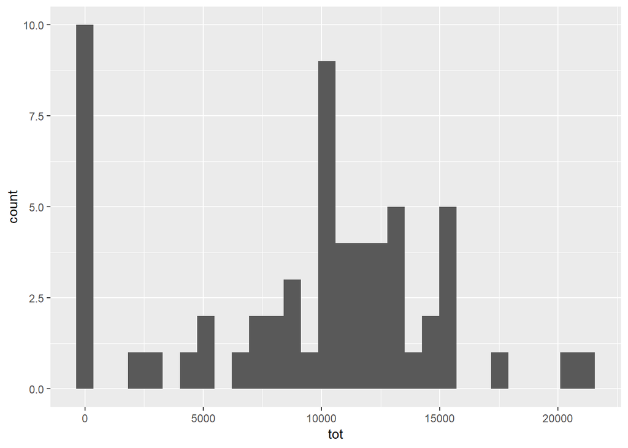

```r
ggplot(data= steps_per_day) +
  geom_histogram(mapping=aes(x=tot))
```

## Task 3: Analysis of Average Daily Activity Pattern

```r
Act_per_TP <- activity%>%group_by(interval)
steps_per_TP <-
  summarise(Act_per_TP,
            avg=mean(steps,na.rm=TRUE))
```

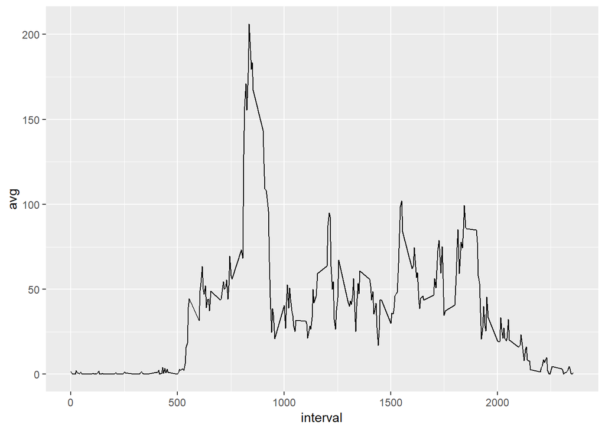

```r
ggplot(data= steps_per_TP, aes(x=interval,y=avg) ) +
  geom_line()
```

```r
max_steps_in_TP <- max(steps_per_TP$avg)
 filter(steps_per_TP,max_steps_in_TP==steps_per_TP$avg)
```

```
## # A tibble: 1 x 2
##   interval   avg
##      <int> <dbl>
## 1      835  206.
```

Table of Mean Steps per Time Period

```r
print.data.frame(steps_per_TP)
```

```
##     interval         avg
## 1          0   1.7169811
## 2          5   0.3396226
## 3         10   0.1320755
## 4         15   0.1509434
## 5         20   0.0754717
## 6         25   2.0943396
## 7         30   0.5283019
## 8         35   0.8679245
## 9         40   0.0000000
## 10        45   1.4716981
## 11        50   0.3018868
## 12        55   0.1320755
## 13       100   0.3207547
## 14       105   0.6792453
```

[output cut: 274 more lines]

## Task 4: Impute missing values

Calculate and report the total number of missing values in the dataset (i.e. the total number of rows with NAs)

```r
Num_NA <- sum(is.na(activity$steps))
Num_NA
```

```
## [1] 2304
```

Devise a strategy for filling in all of the missing values in the dataset. The strategy does not need to be sophisticated. For example, you could use the mean/median for that day, or the mean for that 5-minute interval, etc.

The strategy used in the this analysis: replace the missing steps value with the mean for that time period

Create a new dataset that is equal to the original dataset but with the missing data filled in. dataset = act2

```r
activity <- mutate(activity,rn=1:nrow(activity))


act2 <- merge.data.frame(activity, steps_per_TP,
                 by.x="interval",
                 by.y="interval"
                 )
act2[is.na(act2$steps),"steps"] <- act2[is.na(act2$steps),"avg"]
act2 <- act2[order(act2$rn),]
```

Make a histogram of the total number of steps taken each day

```r
Act2_per_day <- act2%>%group_by(date)
steps2_per_day <-
  summarise(Act2_per_day,
            tot=sum(steps,na.rm=TRUE),
            avg=mean(steps,na.rm=TRUE),
            med=median(steps,na.rm=TRUE))
```

```r
#steps2_per_day
print.data.frame(steps2_per_day)
```

```
##          date      tot        avg      med
## 1  2012-10-01 10766.19 37.3825996 34.11321
## 2  2012-10-02   126.00  0.4375000  0.00000
## 3  2012-10-03 11352.00 39.4166667  0.00000
## 4  2012-10-04 12116.00 42.0694444  0.00000
## 5  2012-10-05 13294.00 46.1597222  0.00000
## 6  2012-10-06 15420.00 53.5416667  0.00000
## 7  2012-10-07 11015.00 38.2465278  0.00000
## 8  2012-10-08 10766.19 37.3825996 34.11321
## 9  2012-10-09 12811.00 44.4826389  0.00000
## 10 2012-10-10  9900.00 34.3750000  0.00000
## 11 2012-10-11 10304.00 35.7777778  0.00000
## 12 2012-10-12 17382.00 60.3541667  0.00000
## 13 2012-10-13 12426.00 43.1458333  0.00000
## 14 2012-10-14 15098.00 52.4236111  0.00000
```

[output cut: 47 more lines]

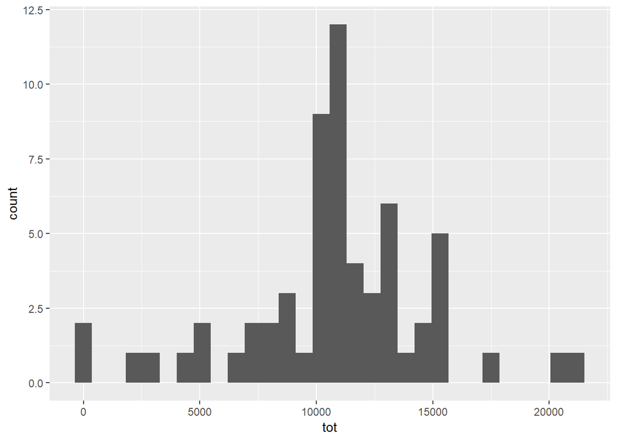

```r
ggplot(data= steps2_per_day) +
  geom_histogram(mapping=aes(x=tot))
```

Calculate and report the mean and median total number of steps taken per day. Do these values differ from the estimates from the first part of the assignment?

```r
cbind(steps_per_day$avg,steps2_per_day$avg,steps_per_day$avg-steps2_per_day$avg)
```

```
##             [,1]       [,2] [,3]
##  [1,]        NaN 37.3825996  NaN
##  [2,]  0.4375000  0.4375000    0
##  [3,] 39.4166667 39.4166667    0
##  [4,] 42.0694444 42.0694444    0
##  [5,] 46.1597222 46.1597222    0
##  [6,] 53.5416667 53.5416667    0
##  [7,] 38.2465278 38.2465278    0
##  [8,]        NaN 37.3825996  NaN
##  [9,] 44.4826389 44.4826389    0
## [10,] 34.3750000 34.3750000    0
## [11,] 35.7777778 35.7777778    0
## [12,] 60.3541667 60.3541667    0
## [13,] 43.1458333 43.1458333    0
## [14,] 52.4236111 52.4236111    0
```

[output cut: 47 more lines]

```r
cbind(steps_per_day$med,steps2_per_day$med,steps_per_day$med-steps2_per_day$med)
```

```
##       [,1]     [,2] [,3]
##  [1,]   NA 34.11321   NA
##  [2,]    0  0.00000    0
##  [3,]    0  0.00000    0
##  [4,]    0  0.00000    0
##  [5,]    0  0.00000    0
##  [6,]    0  0.00000    0
##  [7,]    0  0.00000    0
##  [8,]   NA 34.11321   NA
##  [9,]    0  0.00000    0
## [10,]    0  0.00000    0
## [11,]    0  0.00000    0
## [12,]    0  0.00000    0
## [13,]    0  0.00000    0
## [14,]    0  0.00000    0
```

[output cut: 47 more lines]

```r
median(steps_per_TP$avg)
```

```
## [1] 34.11321
```

What is the impact of imputing missing data on the estimates of the total daily number of steps?

There are fewer time periods with a total steps = 0.

## Task 5: Weekday/Weekend Analysis

Form a factor variable inicating whether a given date is a weekday or weekend day.

```r
weekend <- (wday(ymd(act2$date))==1|wday(ymd(act2$date))==7)*1
act2<- cbind(act2,weekend)
act2$weekend <- as.factor(act2$weekend)
act2$weekend <- plyr::mapvalues(act2$weekend,
                  from=c("0","1"),
                  to = c("Weekday", "Weekend"))
```

Are there differences in activity patterns between weekdays and weekends?

Make a panel plot containing a time series plot (i.e. type=“l”) of the 5-minute interval (x-axis) and the average number of steps taken, averaged across all weekday days or weekend days (y-axis). See the README file in the GitHub repository to see an example of what this plot should look like using simulated data.

```r
Act2_per_TP <- act2 %>% group_by(interval,weekend)
steps2_per_TP <-
  summarise(Act2_per_TP,
            avg=mean(steps,na.rm=TRUE))
```

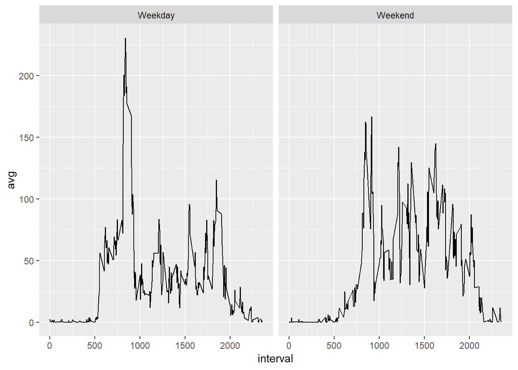

```r
ggplot(data= steps2_per_TP, aes(x=interval,y=avg) ) +
  geom_line() +  facet_wrap(~weekend)
```